# Diamonds quality

```r
library(tidyverse)
library(ggplot2)
```

```r
diamonds <- ggplot2::diamonds |>
  select(-depth, -table, -x, -y, -z)
diamonds
```

```
## # A tibble: 53,940 × 5
##    carat cut       color clarity price
##    <dbl> <ord>     <ord> <ord>   <int>
##  1  0.23 Ideal     E     SI2       326
##  2  0.21 Premium   E     SI1       326
##  3  0.23 Good      E     VS1       327
##  4  0.29 Premium   I     VS2       334
##  5  0.31 Good      J     SI2       335
##  6  0.24 Very Good J     VVS2      336
##  7  0.24 Very Good I     VVS1      336
##  8  0.26 Very Good H     SI1       337
##  9  0.22 Fair      E     VS2       337
## 10  0.23 Very Good H     VS1       338
## # ℹ 53,930 more rows
```

### domanda 1

Innanzitutto, si noti che i diamanti di bassa qualità (per quanto riguarda taglio, colore e purezza) sono più costosi.

Ricordiamo che:

- Il taglio migliore è Ideale, il peggiore è Discreto
- Il colore migliore è D, il peggiore è J
- La chiarezza migliore è IF, la peggiore è I1

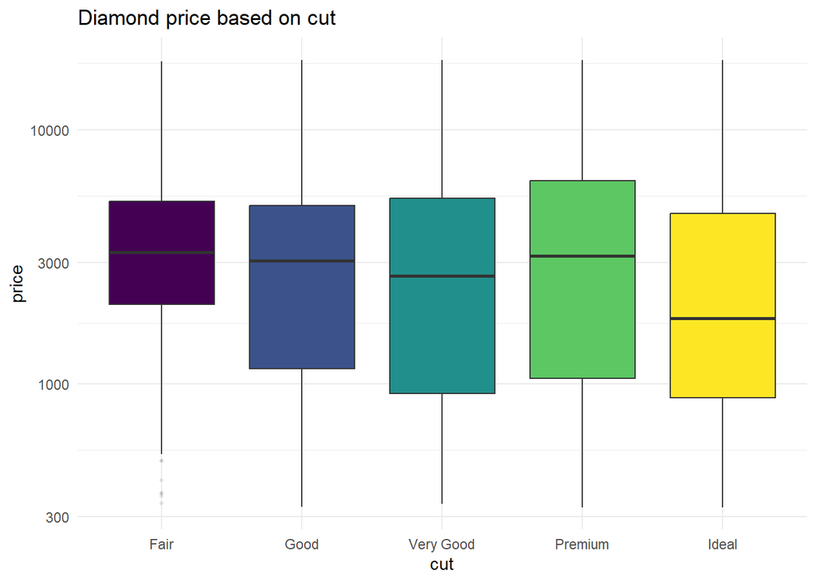

```r
plot_diamanti <- function(nome) {
  nome_testo <- rlang::as_label(rlang::enquo(nome))
  ggplot(diamonds, aes(x = {{ nome }}, y = price, fill = {{ nome }})) +
    geom_boxplot(
      outlier.alpha = 0.1,
      outlier.size = 0.8,
      show.legend = FALSE
    ) +
    scale_y_log10() +
    labs(
      title = paste("Diamond price based on", nome_testo),
      x = nome_testo,
      y = "price"
    ) +
    theme_minimal()
}

plot_diamanti(cut)
```

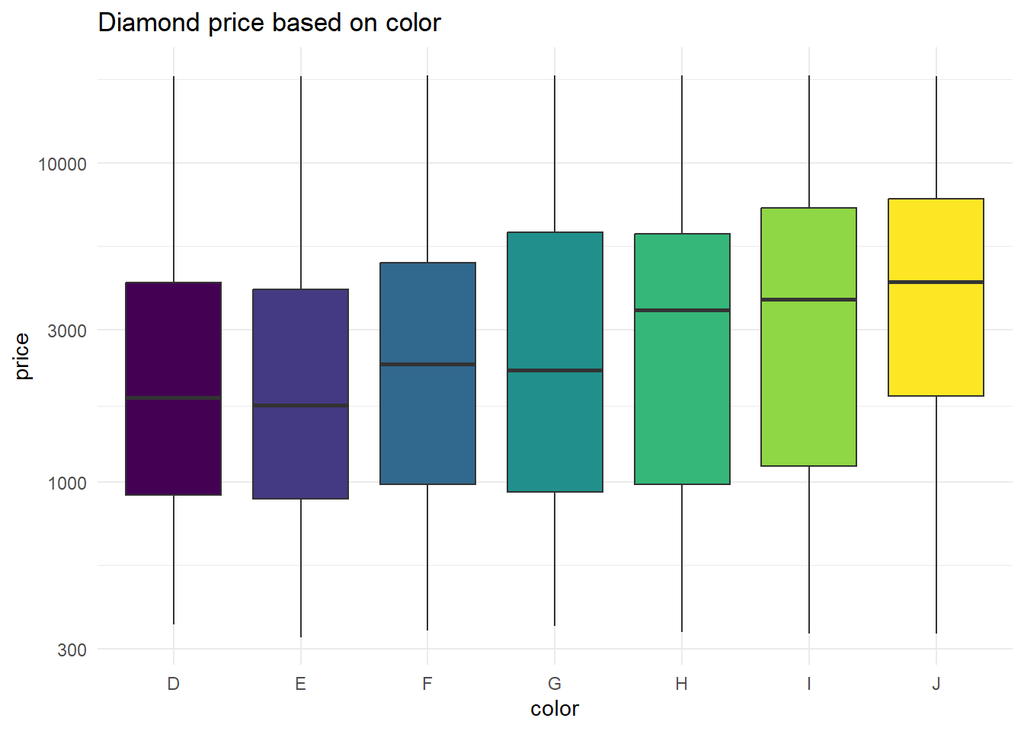

```r
plot_diamanti(color)
```

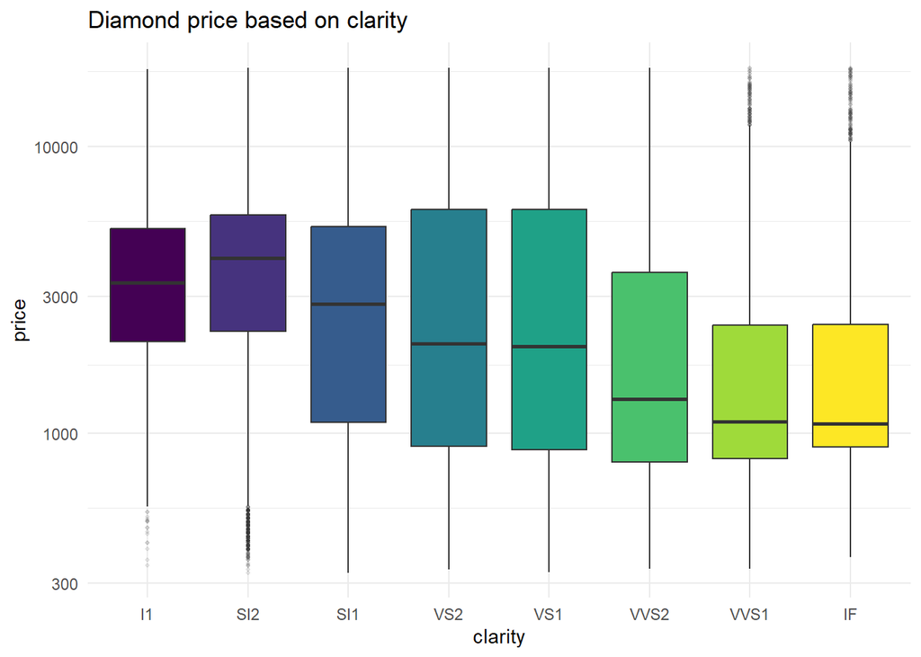

```r
plot_diamanti(clarity)
```

Osservando i tre grafici si può notare che i diamanti di bassa qualità (Fair, J, I1) hanno un prezzo mediano più elevato rispetto ai diamanti di qualità maggiore (Ideal, D, IF).

### domanda 2

Utilizzando dei modelli, trova una spiegazione e risolvi l’apparente paradosso

Analizzando le variabili separatamente, la qualità sembra ridurre il valore del diamante, probabilmente perchè le analisi non tengono in considerazione le altre caratteristiche. E’ quindi importante considerare l’insieme di tutti i fattoti contemporaneamente del diamante traminte un modello

```r
diamonds <- diamonds |>
  mutate(
   cut = factor(cut, levels = c("Fair", "Good", "Very Good", "Premium", "Ideal")),
    color = factor(color, levels = c("J", "I", "H", "G", "F", "E", "D")),
    clarity = factor(clarity, levels = c("I1", "SI2", "SI1", "VS2", "VS1", "VVS2", "VVS1", "IF"))
  )

modello <- lm(log10(price) ~ log10(carat) + cut + color + clarity, data = diamonds)
summary(modello)
```

```
##
## Call:
## lm(formula = log10(price) ~ log10(carat) + cut + color + clarity,
##     data = diamonds)
##
## Residuals:
##      Min       1Q   Median       3Q      Max
## -0.43910 -0.03751 -0.00010  0.03622  0.84591
##
## Coefficients:
##                Estimate Std. Error  t value Pr(>|t|)
## (Intercept)   3.6728414  0.0005071 7242.225  < 2e-16 ***
## log10(carat)  1.8837175  0.0011288 1668.750  < 2e-16 ***
## cut.L         0.0524255  0.0010223   51.284  < 2e-16 ***
## cut.Q        -0.0152501  0.0008997  -16.950  < 2e-16 ***
## cut.C         0.0058539  0.0007811    7.494 6.77e-14 ***
## cut^4        -0.0006782  0.0006258   -1.084    0.278
## color.L       0.1909054  0.0008804  216.828  < 2e-16 ***
## color.Q      -0.0415287  0.0008090  -51.335  < 2e-16 ***
## color.C       0.0064202  0.0007570    8.481  < 2e-16 ***
## color^4       0.0051471  0.0006953    7.403 1.35e-13 ***
## color^5       0.0009559  0.0006569    1.455    0.146
## color^6       0.0010385  0.0005972    1.739    0.082 .
## clarity.L     0.3981752  0.0015537  256.274  < 2e-16 ***
## clarity.Q    -0.1055502  0.0014463  -72.982  < 2e-16 ***
## clarity.C     0.0575006  0.0012396   46.387  < 2e-16 ***
## clarity^4    -0.0287087  0.0009915  -28.955  < 2e-16 ***
## clarity^5     0.0119076  0.0008094   14.711  < 2e-16 ***
## clarity^6    -0.0007899  0.0007051   -1.120    0.263
## clarity^7     0.0145623  0.0006220   23.412  < 2e-16 ***
## ---
## Signif. codes:  0 '***' 0.001 '**' 0.01 '*' 0.05 '.' 0.1 ' ' 1
##
## Residual standard error: 0.05811 on 53921 degrees of freedom
## Multiple R-squared:  0.9826, Adjusted R-squared:  0.9826
## F-statistic: 1.693e+05 on 18 and 53921 DF,  p-value: < 2.2e-16
```

Valutando l’effetto delle caratteristiche qualitative a parità di tutte le altre condizioni, l’aumento della qualità porta sempre a un incremento stimato del prezzo, infatti tutti i coefficienti per taglio, colore e chiarezza mostrano trend positivi e crescenti. Inoltre osservando la tabella è possibile dire che la caratteristica che pesa di più in modo significativo sul prezzo del diamante sono i carati.

Per risolvere il paradosso, è possibile stimare un modello basato solo sul prezzo e sui carati. Analizzando i residui tramite i boxplot per le diverse caratteristiche è possibile confrontare i diamanti a parità di caratura.

```r
modello_carati <- lm(log10(price) ~ log10(carat), data = diamonds)

diamonds_res <- diamonds |>
  mutate(price_res = resid(modello_carati))
diamonds_res
```

```
## # A tibble: 53,940 × 6
##    carat cut       color clarity price price_res
##    <dbl> <fct>     <fct> <fct>   <int>     <dbl>
##  1  0.23 Ideal     E     SI2       326   -0.0864
##  2  0.21 Premium   E     SI1       326   -0.0202
##  3  0.23 Good      E     VS1       327   -0.0850
##  4  0.29 Premium   I     VS2       334   -0.245
##  5  0.31 Good      J     SI2       335   -0.292
##  6  0.24 Very Good J     VVS2      336   -0.104
##  7  0.24 Very Good I     VVS1      336   -0.104
##  8  0.26 Very Good H     SI1       337   -0.161
##  9  0.22 Fair      E     VS2       337   -0.0396
## 10  0.23 Very Good H     VS1       338   -0.0707
## # ℹ 53,930 more rows
```

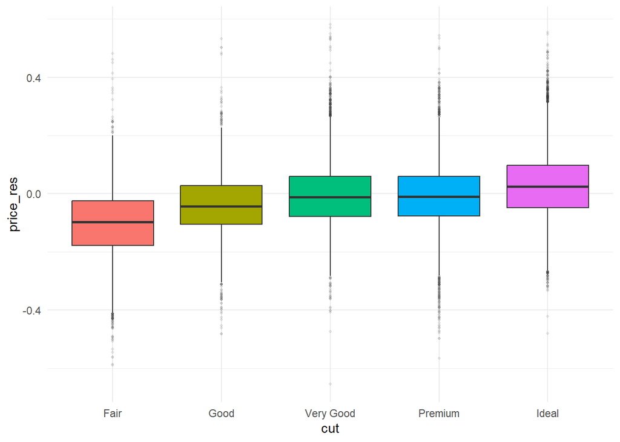

```r
plot_residui <- function(nome) {
  nome_testo <- rlang::as_label(rlang::enquo(nome))
  ggplot(diamonds_res, aes(x = {{ nome }}, y = price_res, fill = {{ nome }})) +
    geom_boxplot(
      outlier.alpha = 0.1,
      outlier.size = 0.8,
      show.legend = FALSE
    ) +
    labs(
      x = nome_testo,
      y = "price_res"
    ) +
    theme_minimal()
}

plot_residui(cut)
```

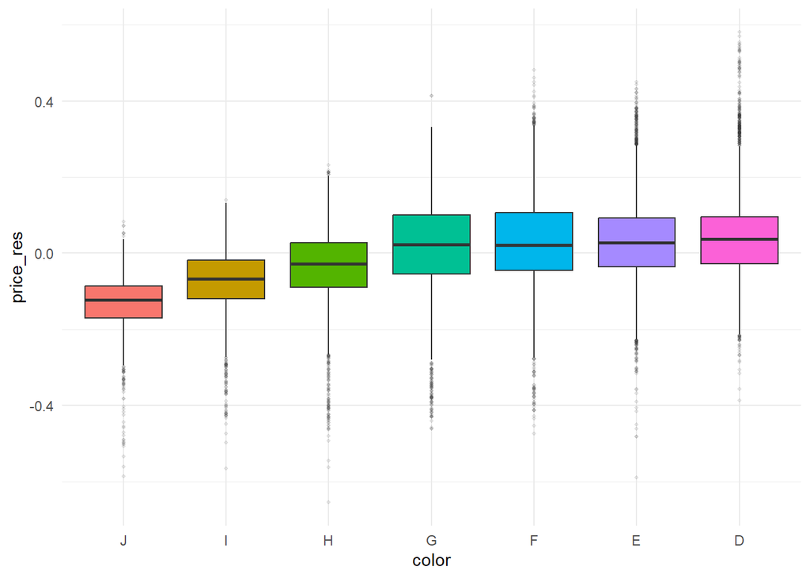

```r
plot_residui(color)
```

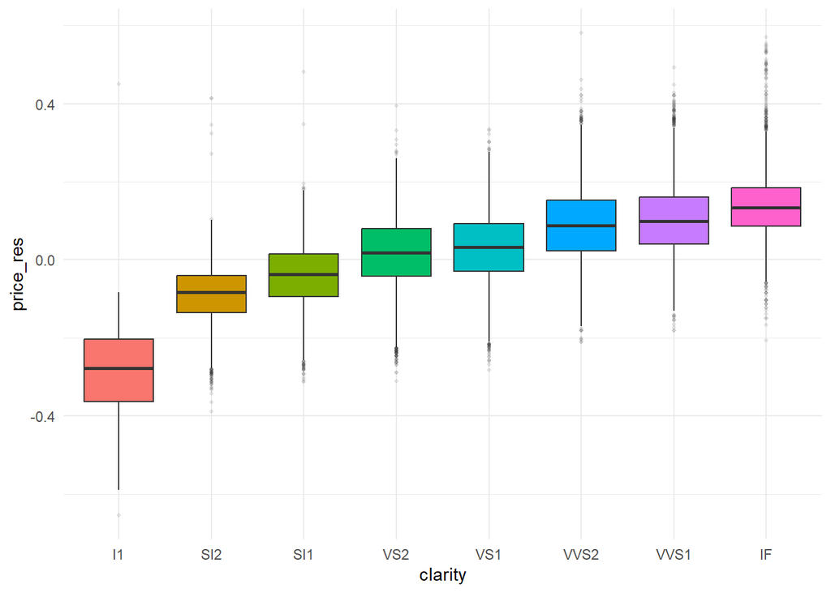

```r
plot_residui(clarity)
```

I grafici dimostrano che, a parità di carati, il prezzo aumenta insieme alla qualità: le mediane crescono in modo ordinato per il taglio (da Fair ad Ideal), per la purezza (da I1 ad IF) e per il colore (da J a D).